# Project Proposal

Amanda, Tony, Harry, Geena

## Data Sets

- [Austin Animal Center Intakes](https://data.austintexas.gov/Health-and-Community-Services/Austin-Animal-Center-Intakes/wter-evkm/about_data): This dataset logs all of the Austin Animal Shelter Intakes (the animals that enters the shelter), and keeps track of the time the animal was taken in, where it was found, the intake type (stray, owner surrenders, etc), intake conditions of the animal, what type/breed the animal is, age upon intake, and a color description of the animal. The dataset begins from Oct 1st, 2013, and is updated regularly.
- [Austin Animal Center Outcomes](https://data.austintexas.gov/Health-and-Community-Services/Austin-Animal-Center-Outcomes/9t4d-g238/about_data): This dataset mirrors the Intakes dataset, except it records data about the animals that leave the shelter, whether it is because of an adoption, transfer (of shelter/facilities), or euthanasia. This dataset has the same variables as the intakes dataset, with the addition of the outcome type (in place of intake type/condition), and has date of birth as well.

For this project, because of the immense size of the data set, we will be using only data from 2024 (Jan 1-Dec 31, 2024). Our final dataset will join the intakes and outcomes dataset into one that only has information about animals that were taken in and left the shelter in 2024, with the key variables: Intake Type, Intake Condition, Animal Type, Sex (including if they were spayed/neutered), Age, Outcome Type, Outcome Date, Date of Birth, and Length of Stay (which was calculated from the outcome date - intake date).

Here is a sample of our final data set:

```
## # A tibble: 6 × 16
##   `Animal ID` Name         IntakeType     IntakeCondition AnimalType Sex     Age
##   <chr>       <chr>        <chr>          <fct>           <fct>      <fct> <dbl>
## 1 A495162     Mr Manly Man Public Assist  Medical         Cat        Neut…    16
## 2 A510858     Shiva        Owner Surrend… Normal          Cat        Spay…    16
## 3 A557091     Bartina      Owner Surrend… Normal          Cat        Spay…    16
## 4 A557091     Bartina      Owner Surrend… Normal          Cat        Spay…    16
## 5 A566659     Buddy        Stray          Medical         Dog        Neut…    16
## 6 A566837     Chica        Stray          Normal          Cat        Spay…    15
## # ℹ 9 more variables: OutcomeType <chr>, OutcomeDate <date>,
## #   LengthofStay <dbl>, DOB <date>, log_LOS <dbl>, log_Age <dbl>,
## #   sqrt_Age <dbl>, Adoption <dbl>, age2 <dbl>
```

## Questions

For each question, you need to include initial results, such as figures/ plots and some simple analyses (e.g., linear and non-linear models, tree-based methods, etc.).

**Q1 - Using the available predictors, is it possible to predict the length of stay of an animal that comes into the Austin animal shelter?**

Looking at the variables in our dataset, it seems like most of the predictors would have a relationship with the length of stay - especially the animal type, gender, and age, but maybe also how the animal was introduced to the shelter.

There seems to be a pretty extreme skew in both of our numeric variables, so we look at the relationship between the log transforms of both:

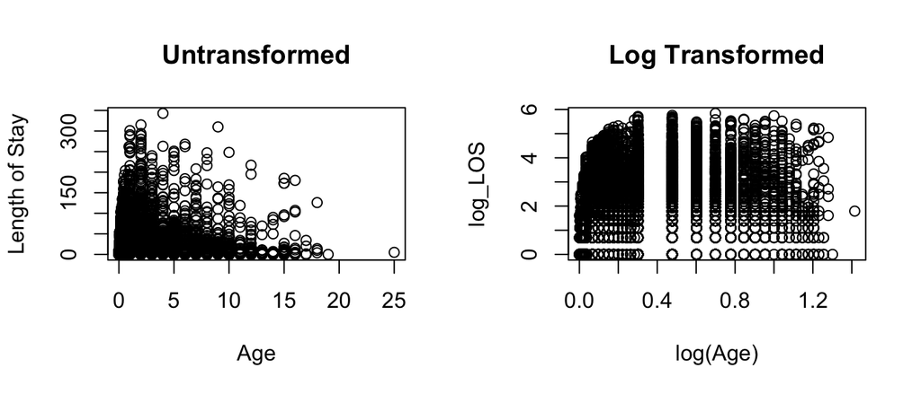

We can run an initial linear regression (with the log of both numeric variables) to see if there are any linear relationships.

```
## [1] "Adjusted R Squared 0.385994438482036"
```

```
## [1] "Mean RMSE from k=10 CV:  1.06424876386094"
```

**Q2 - Can we predict adoptability based on the age upon intake?**

```r
mean(shelter_clean$Adoption)
```

```
## [1] 0.6103414
```

About 61% animals were adopted in the dataset.

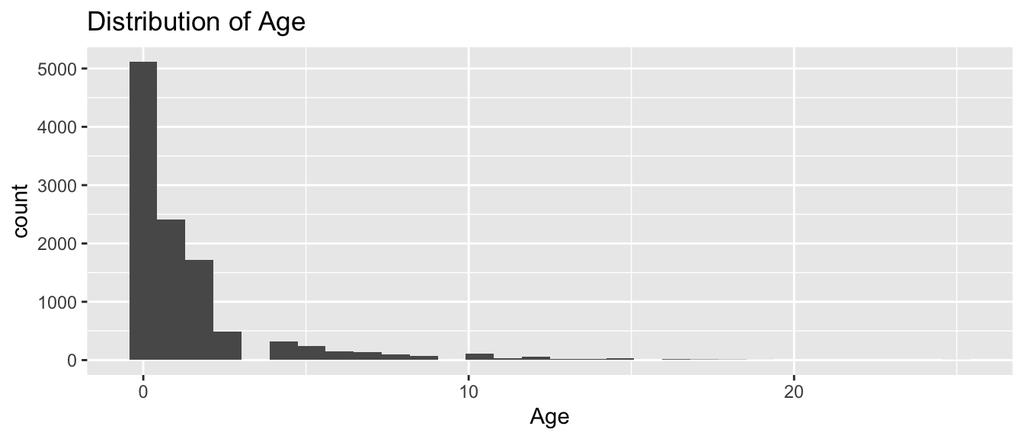

```
## glm(formula = Adoption ~ Age, family = "binomial", data = shelter_clean)
```

```
##               Estimate  Std. Error   z value      Pr(>|z|)
## (Intercept)  0.6252413 0.023545088  26.55506 2.244634e-155
## Age         -0.1100936 0.008110217 -13.57468  5.658892e-42
```

The output gives the logit-form of the model which is: ln(p hat / 1-p hat) = 0.62524 - 0.11009 * Age, where p hat is the probability of the animal being adopted (1 = adopted).

Here is a visualization of how our logistic regression is categorizing our variables. As you can see, our model is making a lot of errors. Maybe in the future we could consider more predictors, or try another classification method such as a classification tree.

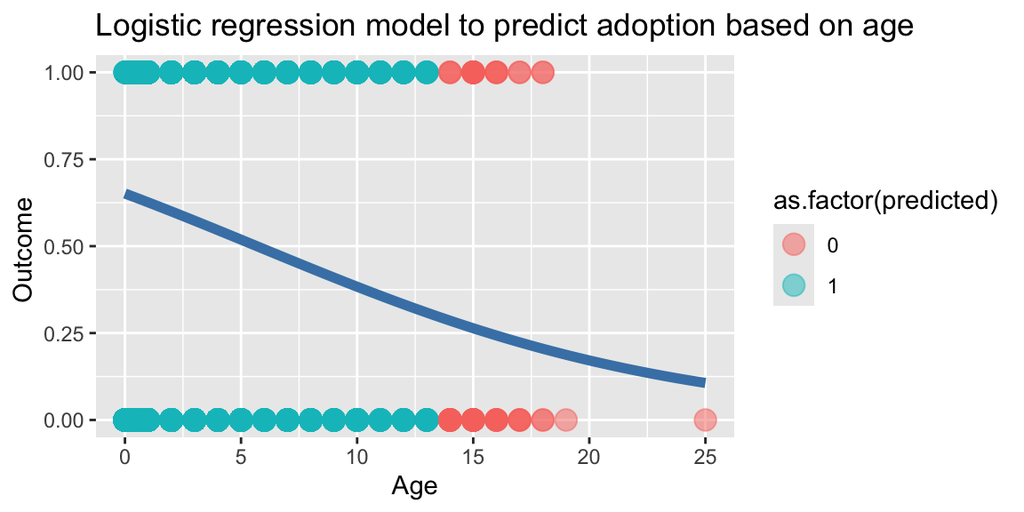